# Curso Teórico y Práctico en Análisis Metagenómico - Universidad de los Andes

Guía 04. Introducción al análisis funcional en metagenomas

Profesores:** Alejandro Reyes Muñoz, Maryam Chaib De Mares, Alejandro Castellanos Sánchez

Noviembre 18, 2022

# 1 La predicción de genes

La predicción de genes es el proceso de determinar dónde podría estar un región codificante en una secuencia genómica. En la **Figura 1** se muestra cómo se pueden usar los marcos abiertos de lectura (ORF) para la predicción de genes. Las proteínas funcionales deben comenzar con un codón de inicio (donde comienza la transcripción del ADN) y terminar con un codón de parada (donde termina la transcripción). Al observar dónde podrían caer esos codones en una secuencia de ADN, uno puede ver dónde podría ubicarse una proteína funcional. En este ejemplo, se puede descubrir una proteína funcional usando el ORF3 porque comienza con un codón de inicio, tiene múltiples aminoácidos y luego termina con un codón de terminación, todo dentro del mismo marco de lectura.

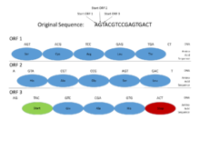

**Figura 1.** Tomado de: https://en.wikipedia.org/wiki/Gene_prediction

La anotación estructural de genes va de la mano con la anotación funcional. La predicción de la función a partir de la estructura se puede lograr mediante la comparación global de las estructuras de proteínas para detectar la homología o mediante el uso de señales estructurales derivadas de los sitios activos de las enzimas o de las unidades mínimas de las proteínas como lo son los dominios. Una herramienta que realiza esta predicción tanto estructural como funcional es ce *prokka*, la cual usaremos inicialmente para realizar búsquedas manuales de genes de interés.

Ingrese nuevamente al servidor empleando el comando `ssh` como se ha indicado anteriormente.

```bash
ssh -p 2989 sesinchi@190.26.196.154
```

## 1.1 Uso de PROKKA (¡Hands On!)

### 1.1.1 Anotar el ensamblaje usando el flujo de PROKKA

Ahora que ha ensamblado los metagenomas en contigs, el siguiente paso es la anotación de los datos, es decir, encontrar los genes y hacer una anotación funcional de aquellos. Hay una variedad de programas disponibles para estas tareas, pero aquí usaremos `PROKKA <http://www.vicbioinformatics.com/software.prokka.shtml>`_, que es esencialmente un flujo que comprende varias herramientas y bases de datos bioinformáticos de código abierto.

PROKKA automatiza el proceso de localización de marcos de lectura abiertos (ORF) y regiones de ARN en contigs, traducir ORF a secuencias de proteínas, buscar homólogos de proteínas y producir archivos de salida estándar. Para la búsqueda y traducción de genes, PROKKA hace uso del programa `Prodigal <http://prodigal.ornl.gov/>`*. Luego se realiza la búsqueda de homología (a través de alineamiento y HMMER) utilizando las secuencias de proteínas traducidas como consultas contra un conjunto de bases de datos públicas (`CDD <http://www.ncbi.nlm.nih.gov/cdd/>`*, `PFAM <pfam.xfam.org/>`*, `TIGRFAM <http://www.jcvi.org/cgi-bin/tigrfams/index.cgi>`*) así como bases de datos personalizadas que vienen con PROKKA.

Vaya al directorio indicado a continuación e imprima en la terminal los comandos de ayuda del programa:

```bash
cd /home/sesinchi/curso-uniandes/usuario-sinchi/08-metagenomes-annotation
prokka -h
```

y ejecute PROKKA sobre el ensamblaje presente en la ruta absoluta indicada abajo. ¿Cómo lo haría?

```bash
/home/sesinchi/curso-uniandes/usuario-sinchi/04-metagenomes-assembly/
```

Reemplace $SAMPLE con el archivo de interés y ejecute el comando:

```bash
prokka contigs.fa --outdir $SAMPLE --norrna --notrna --metagenome --cpus 8
cd $SAMPLE
```

PROKKA produce varios tipos de archivos de salida como:

- Un archivo tipo `GFF <http://genome.ucsc.edu/FAQ/FAQformat.html>`_, que es un formaro estandarizado, delimitado por tabs, para anotaciones de (meta)genomas.
- Un archivo tipo `Genbank <http://www.ncbi.nlm.nih.gov/Sitemap/samplerecord.html>`_ (**GBK**), que es una descripción más detallada de las secuencias de nucleótidos y los genes codificados por estas.

Cuando sus datos hayan sido anotados, puede ver las anotaciones directamente en el archivo GFF. PROKKA nombra los archivos resultantes según la fecha actual, así: `PROKKA_mmddyyyy`.

Ahora, visualice partes del archivo con el comando:

```
less -S PROKKA_11192022.gff
```

Notará que las primeras líneas en el archivo GFF muestran las regiones de secuencia anotadas. Para omitir estos y acceder directamente a las anotaciones, puede hacer lo siguiente:

```
grep -v "^#" PROKKA_11192022 | less -S
```

El símbolo (^) busca una correspondencia al inicio de cada línea, y el parámetro ‘-v’ significa que estas líneas deben omitirse. Las líneas restantes se pasan al comando `less`.

**Pregunta: ¿Cuántas regiones codificantes encontró Prodigal? Sugerencia: use grep -c para contar líneas**

Algunos genes en su conjunto de datos ahora deberían contener anotaciones e identificadores de varias bases de datos, como `enzyme comission <http://enzyme.expasy.org/>`_ y `COG <http://www.ncbi.nlm.nih.gov/COG/>`_ (Clusters of Orthologous Groups).

**Pregunta: ¿A cuántas de las regiones codificantes se les dio un identificador E.C.? ¿A cuántas se les dio un identificador COG?**

En los análisis posteriores, cuantificaremos y compararemos la abundancia de enzimas y rutas metabólicas, así como los COG en las diferentes muestras. Para hacer esto, primero extraeremos listas de genes con ID de enzima y COG del archivo GFF que produjo PROKKA. Primero buscamos líneas que contengan números de enzimas usando la coincidencia de patrones con grep y luego reformateamos la salida usando una combinación de `cut` y `sed` ::

```
grep "eC_number=" PROKKA_11192022.gff | cut -f9 | cut -f1,2 -d ';'| sed 's/ID=//g'| sed 's/;eC_number=/\t/g' > PROKKA.$SAMPLE.ec
```

**Asegúrese de entender lo que hacen las diferentes partes de estas líneas de código. Intente eliminar partes entre los símbolos de “pipe” (‘|’) y vea cómo esto cambia la salida.**

El siguiente paso es predecir las rutas metabólicas en la muestra en función de las enzimas anotadas por PROKKA.

## 1.2 Predicción de rutas metabólicas con MinPath

Una forma de predecir las rutas metabólicas en una muestra es simplemente considerar todas las rutas en las que participa un conjunto de enzimas. Sin embargo, esto puede sobrestimar las rutas, por ejemplo, si solo se anotan en la muestra algunas de las enzimas requeridas para una ruta. En este caso vamos a predecir las rutas metabólicas usando el programa `MinPath`_ para obtener una estimación conservadora de las vías presentes. MinPath solo considera el número mínimo de rutas requeridas para explicar el conjunto de enzimas en la muestra. Como entrada, MinPath requiere 1) un archivo con identificadores de genes y números de enzimas, separados por tabulaciones, y 2) un archivo que vincule cada enzima a una o varias vías. El primero de estos lo producimos arriba utilizando la coincidencia de patrones del archivo PROKKA gff. El segundo archivo existe en dos versiones, una que vincula enzimas a vías definidas en la base de datos Metacyc y otra que vincula enzimas a vías definidas en la base de datos KEGG.

Identifique los archivos en:

```bash
cd /home/sesinchi/curso-uniandes/usuario-sinchi/09-metabolic-paths/
```

Cargue el software necesario para la sesión 4 con el comando:

```bash
conda activate session4
```

Ejecute MinPath con este comando para predecir rutas Metacyc::

```
MinPath1.2.py -any PROKKA.$SAMPLE.ec -map ~/mg-workshop/reference_db/metacyc/ec.to.pwy -report PROKKA.$SAMPLE.metacyc.minpath > MinPath.Metacyc.$SAMPLE.log
```

Revise la salida:

```
less -S PROKKA.$SAMPLE.metacyc.minpath
```

**Pregunta: ¿Cuántas rutas Metacyc predijo MinPath en su muestra?**

Para aprender a interpretar el reporte, consulte el recurso: [How to read the MinPath report file?](https://omics.informatics.indiana.edu/MinPath/output-readme.txt).

## 1.3 Mapeando lecturas y cuantificando genes

Hasta ahora solo tenemos el número de genes y anotaciones en la muestra. Debido a que estas anotaciones se predicen a partir de lecturas ensambladas, hemos perdido la cuantificación para las anotaciones. Entonces, para realmente **cuantificar** los genes, mapearemos las lecturas de nuevo al ensamblaje.

En este tutorial vamos a usar `bowtie2 <http://bowtie-bio.sourceforge.net/bowtie2/index.shtml>`, ver la documentación `Bowtie2 documentation <http://bowtie-bio.sourceforge.net/bowtie2/manual.shtml>`*. Este proceso resulta normalmente en un formato `SAM o BAM <http://genome.sph.umich.edu/wiki/SAM>`*. Esos son formatos que contienen la información del resultado de los alineamientos, donde BAM es la versión binaria del formato SAM de texto plano. `BEDTools <http://code.google.com/p/bedtools/>`_ se puede usar luego para recuperar las estadísticas de cobertura.

Identifique los archivos que requiere para el proceso de mapeo. Luego, corra el comando `bowtie2-build` sobre el archivo del ensamblaje:

```
bowtie2-build contigs.fa contigs.fa
```

Después corra el mapeo con el comando `bowtie2` pero modifique las entradas con las rutas relativas a las lecturas que dieron lugar al ensamblaje:

```
bowtie2 -p 8 -x contigs.fa -1 pair1.fastq -2 pair2.fastq -S $SAMPLE.map.sam
```

El archivo SAM de salida debe convertirse al formato BAM. Para esto usaremos `samtools <http://samtools.sourceforge.net/>`_. Primero, debe crearse un índice sobre el ensamblaje usando samtools:

```
samtools faidx contigs.fa
```

Luego, el archivo SAM se convierte a formato BAM (`view`), se ordena por la coordenada alineada más a la izquierda (`sort`) y luego se debe indexar (`index`) para agilizar el acceso:

```
samtools view -bt contigs.fa.fai $SAMPLE.map.sam > $SAMPLE.map.bam
samtools sort $SAMPLE.map.bam $SAMPLE.map.sorted
samtools index $SAMPLE.map.sorted.bam
```

## 1.4 Calculando la cobertura

Ahora hemos asignado las lecturas al ensamblaje y tenemos información sobre qué parte del mismo está cubierto por las lecturas en la muestra. Pero ahora, estamos interesados en la cobertura de cada uno de los genes anotados en los pasos anteriores por el flujo de PROKKA. Para extraer esta información del archivo BAM, primero debemos definir las regiones para calcular la cobertura. Esto lo haremos creando un archivo BED que defina las regiones de interés (los genes anotados por PROKKA). Aquí usamos un script bash llamado *prokkagff2bed.sh* que busca las regiones genéticas en la salida de PROKKA y luego los imprime en un formato adecuado::

```
prokkagff2bed.sh SAMPLE/PROKKA_11242015.gff > $SAMPLE.map.bed
```

Luego se usa `bedtools <https://code.google.com/p/bedtools/>`_ para extraer información de cobertura del archivo BAM para las regiones definidas en el archivo BED que acabamos de crear::

```
bedtools coverage -hist -abam $SAMPLE.map.sorted.bam -b $SAMPLE.map.bed > $SAMPLE.map.hist
```

**Pregunta: ¿Qué información le aporta el archivo de salida?**

Luego, para cada gen se calcula la profundidad usando el script *get_coverage_for_genes.py*:

```
get_coverage_for_genes.py -i <(echo $SAMPLE.map.hist) > $SAMPLE.coverage
```

Ahora tenemos valores de cobertura para todos los genes predichos y anotados por el flujo de PROKKA. A continuación, utilizaremos las anotaciones y los valores de cobertura para resumir las anotaciones de la muestra.

Usaremos KRONA para visualizar las abundancias de las jerarquías funcionales de manera interactiva. Las anotaciones de enzimas de PROKKA son particularmente adecuadas para este propósito porque estas anotaciones se pueden agrupar en categorías funcionales más altas, como rutas (p. ej., glucólisis) y clases de rutas (p. ej., metabolismo energético).

Ahora, usaremos el script *genes.to.kronaTable.py* para producir la salida tabular necesaria para KRONA a partir de las rutas predichas por MinPath::

```
genes.to.kronaTable.py -i PROKKA.$SAMPLE.ec -m ec.to.pwy -H pwy.hierarchy -n $SAMPLE -l <(grep "minpath 1" PROKKA.$SAMPLE.metacyc.minpath) -c $SAMPLE.coverage -o $SAMPLE.krona.metacyc.minpath.tab
```

Finalmente, use el script ktImportText de Kronatools para generar los archivos HTML::

```
ktImportText -o $SAMPLE.krona.metacyc.minpath.html $SAMPLE.krona.metacyc.minpath.tab
```

Copie los archivos html resultantes a su computadora local con scp como antes y ábralos en un navegador, como lo hizo para la salida de FastQC.